# Chapter 7 Homework

### Telemarketing Data

We will consider the telemarketing data from chapter 3, where the goal is to predict the probability that a call results in a subscription (`subscribe=1`) for a term deposit product from the bank.

**Fit a CART tree to predict whether or not a call results in a subscrpition. Plot the resulting tree as a dendrogram. What does it look like is the most important variable?**

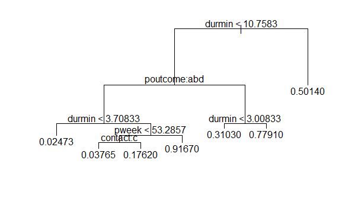

```r
tlmrk <- read.csv("telemarketing.csv", strings=T)
library(tree)
treeTD <- tree( subscribe==1 ~ ., data=tlmrk, )
plot(treeTD)
text(treeTD)
```

The earliest, and most, splits are on `durmin` the length of the call.

**Sample a random test sample of 1000 observations. Fit a random forest to predict the subscription probability, using only the training sample. What is the most important variable? Compare predictive performance on the test sample to the lasso regression from Chapter 3.**

First, split the data into test and train.

```r
set.seed(1)
testi <- sample.int(nrow(tlmrk),1000)
test <- tlmrk[testi,]
train <- tlmrk[-testi,]
dim(test)
```

```
[1] 1000   15
```

```r
dim(train)
```

```
[1] 3521   15
```

Fit the model using ranger.

```r
library(ranger)
rfTD <- ranger(subscribe ~ ., data=tlmrk,
               prob=TRUE, num.tree=200, importance="impurity")
sort(rfTD$variable.importance, decreasing=TRUE)
```

```
    durmin    balance        age      pweek   poutcome        job
232.255059  76.051423  74.468746  44.969406  40.534650  33.389461
  campaign   previous  education    marital    contact    housing
 25.661088  19.304622  18.803754  17.027700  16.944996  14.785729
      loan    default
  6.610131   2.679436
```

Durmin is the most important variable.

Now, fit the lasso logistic regression from Chapter 3.

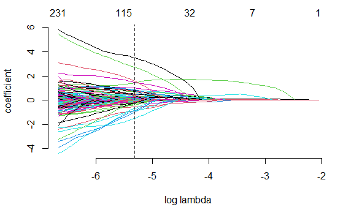

```r
library(gamlr)
tlmrkX <- naref(tlmrk[,-15])
## sparse model matrix
xTD <- sparse.model.matrix(~.^2 + I(durmin^2), data=tlmrkX)
## fit the lasso path
fitTD <- gamlr(xTD[-testi,], tlmrk$subscribe[-testi], family="binomial")
plot(fitTD)
```

Compare the out of sample prediction results. You can compare on deviance or misclassification rates.

```r
plasso <- predict(fitTD, xTD[testi,], type="response")
# random forest predictions are the second column (it produces a matrix)
prf <- predict(rfTD, test)$predictions[,2]

# deviance
#lasso
-2*mean( log(plin)*test$subscribe + log(1-plin)*(1-test$subscribe) )
```

```
[1] 0.5088791
```

```r
#rf
-2*mean( log(prf)*test$subscribe + log(1-prf)*(1-test$subscribe) )
```

```
[1] 0.263994
```

```r
# misclassification rate
mean(  (plin<=0.5)*test$subscribe + (plin>0.5)*(1-test$subscribe) )
```

```
[1] 0.094
```

```r
mean(  (prf<=0.5)*test$subscribe + (prf>0.5)*(1-test$subscribe) )
```

```
[1] 0.045
```

In both cases, OOS ‘errors’ for the RF are about 1/2 those from the lasso logistic regression.